# Lab 4 The Normal Distribution

Author Name

2021-02-26

```r
library(tidyverse)
library(openintro)
```

# Exercise 1

### Make a plot (or plots) to visualize the distributions of the amount of calories from fat of the options from these two restaurants. How do their centers, shapes, and spreads compare?

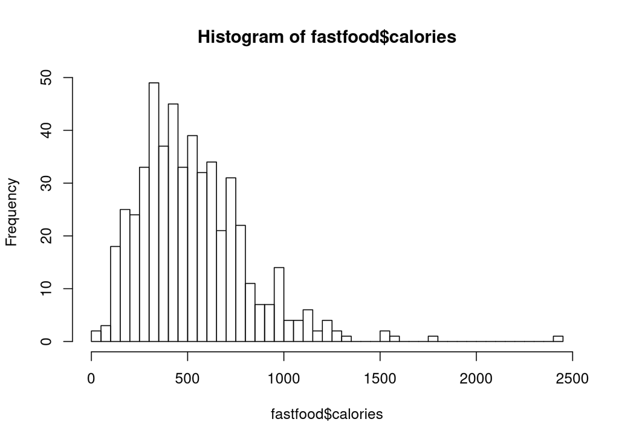

```r
mcdonalds <- fastfood %>%
  filter(restaurant == "Mcdonalds")

dairy_queen <- fastfood %>%
  filter(restaurant == "Dairy Queen")
hist(fastfood$calories, breaks = 50)
```

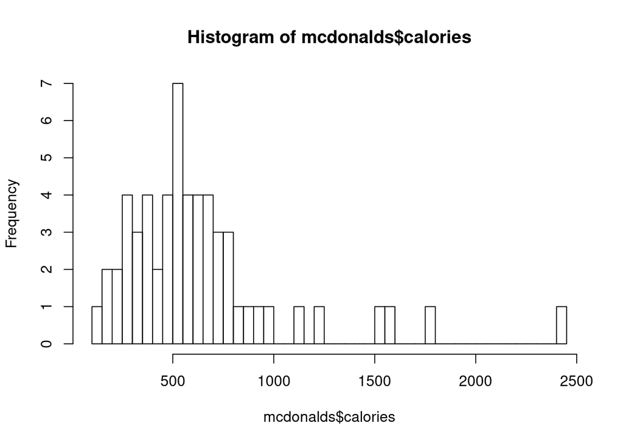

```r
hist(mcdonalds$calories, breaks = 50)
```

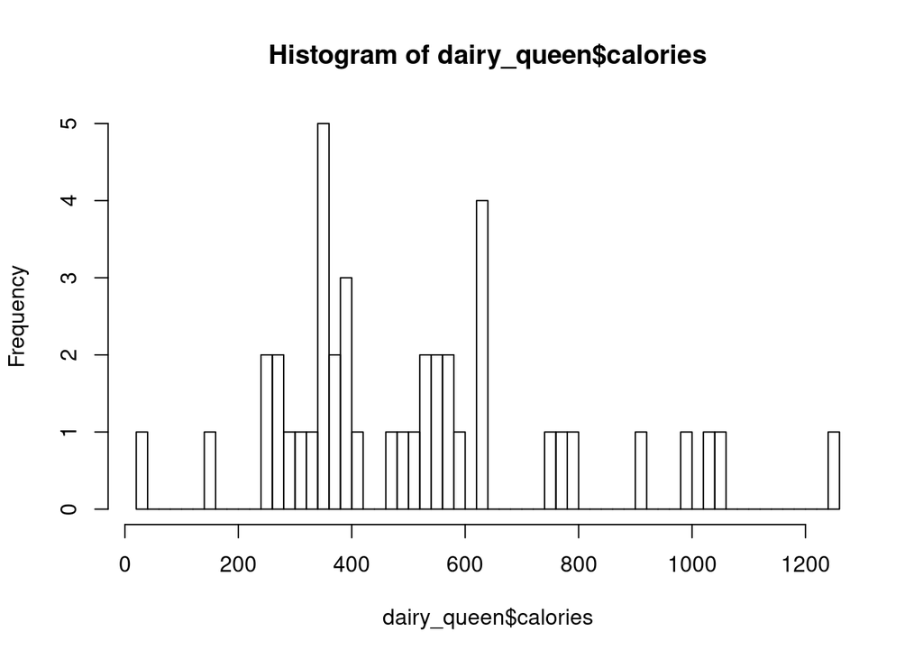

```r
hist(dairy_queen$calories, breaks = 50)
```

mcdonalds contains 57 observations, and dairy_queen has 42… mcdonalds$calories is definitely monomodal skewed right, and it appears dairy_queen$calories is polymodal but the symmetry is not obvious.

```r
dqMean <- mean(dairy_queen$calories)
dqMedian <- median(dairy_queen$calories)
dqSD <- sd(dairy_queen$calories)

mcdoMean <- mean(mcdonalds$calories)
mcdoMedian <- median(mcdonalds$calories)
mcdoSD <- sd(mcdonalds$calories)
```

# Exercise 2

I would say that both are close to being normalized, but they can’t be considered symmetrical.

# Exercise 3

### Make a normal probability plot of sim_norm. Do all of the points fall on the line? How does this plot compare to the probability plot for the real data? (Since sim_norm is not a dataframe, it can be put directly into the sample argument and the data argument can be dropped.)

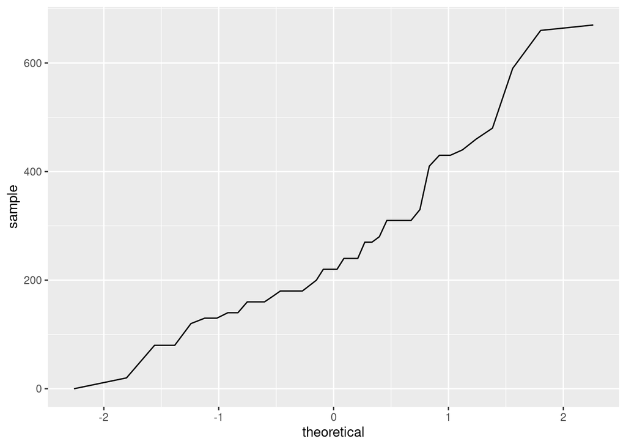

```r
ggplot(data = dairy_queen, aes(sample = cal_fat)) +
  geom_line(stat = "qq")
```

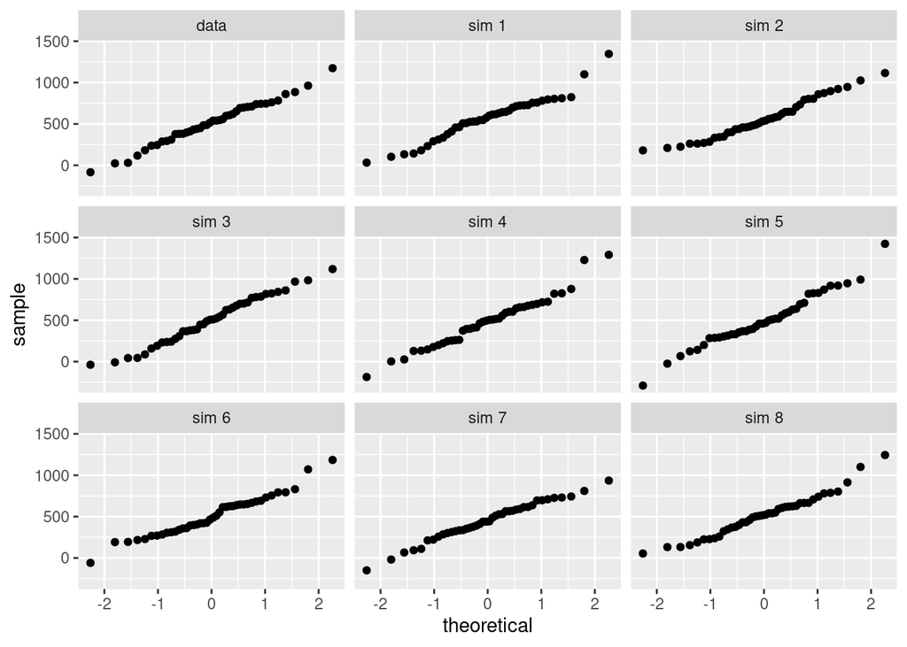

```r
sim_norm <- rnorm(n = nrow(dairy_queen), mean = dqMean, sd = dqSD)
qqnormsim(sample = sim_norm, data = dairy_queen)
```

All the simulations show pretty much the same as the data.

# Exercise 4

### Does the normal probability plot for the calories from fat look similar to the plots created for the simulated data? That is, do the plots provide evidence that the female heights are nearly normal?

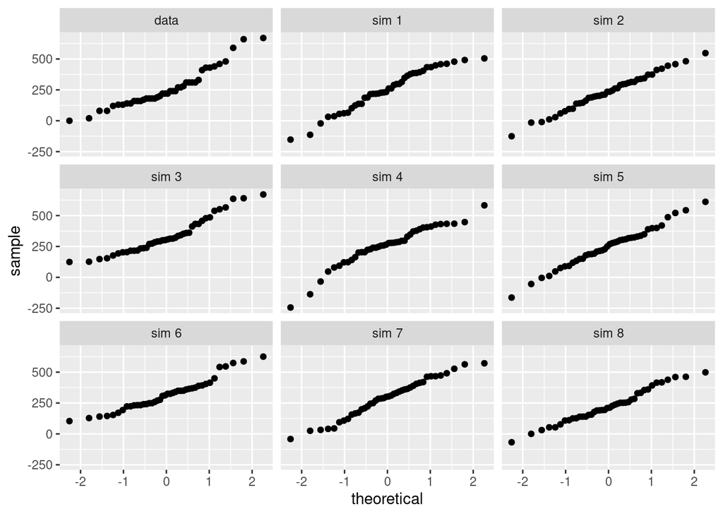

```r
qqnormsim(sample = cal_fat, data = dairy_queen)
```

# Exercise 5

### Using the same technique, determine whether or not the calories from McDonald’s menu appear to come from a normal distribution.

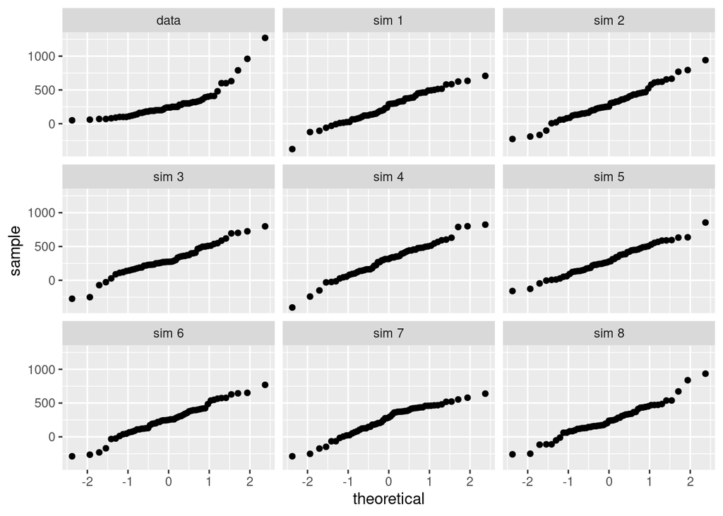

```r
qqnormsim(sample = cal_fat, data = mcdonalds)
```

In this case, no, the data are only linear until just greater than 1 deviation.

# Exercise 6

### Write out two probability questions that you would like to answer about any of the restaurants in this dataset. Calculate those probabilities using both the theoretical normal distribution as well as the empirical distribution (four probabilities in all). Which one had a closer agreement between the two methods?

Is the cholesterol level of Arby’s normally distributed? Is the sodium level of Arby’s normally distributed?

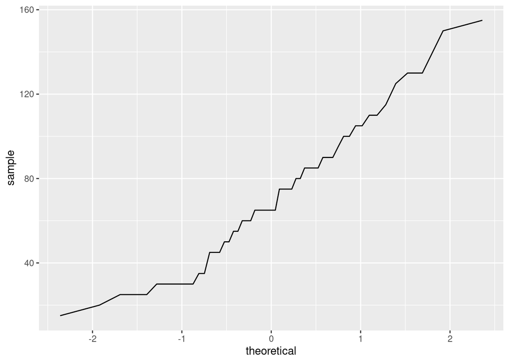

```r
arbys <- fastfood %>%
  filter(restaurant == "Arbys")

a1Mean <- mean(arbys$cholesterol)
a2Mean <- mean(arbys$sodium)

a1SD <- sd(arbys$cholesterol)
a2SD <- sd(arbys$sodium)
a1norm <- rnorm(n = nrow(arbys), mean = a1Mean, sd = a1SD)
a2norm <- rnorm(n = nrow(arbys), mean = a2Mean, sd = a2SD)

ggplot(data = arbys, aes(sample = cholesterol)) +
  geom_line(stat = "qq")
```

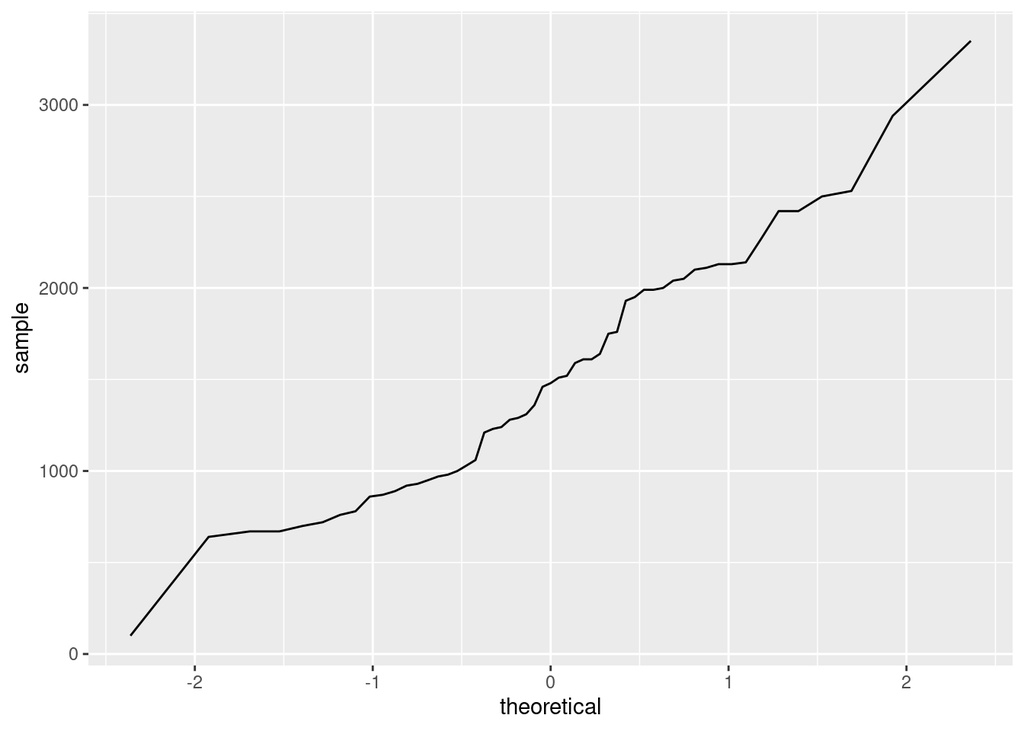

```r
ggplot(data = arbys, aes(sample = sodium)) +
  geom_line(stat = "qq")
```

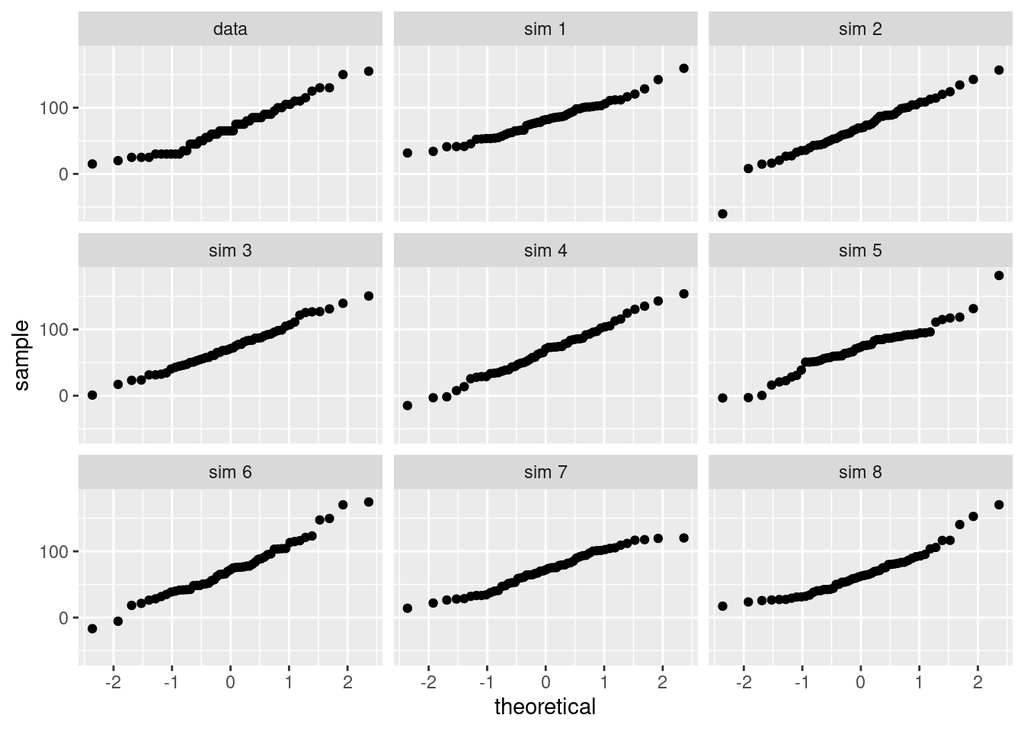

```r
qqnormsim(sample = cholesterol, data = arbys)
```

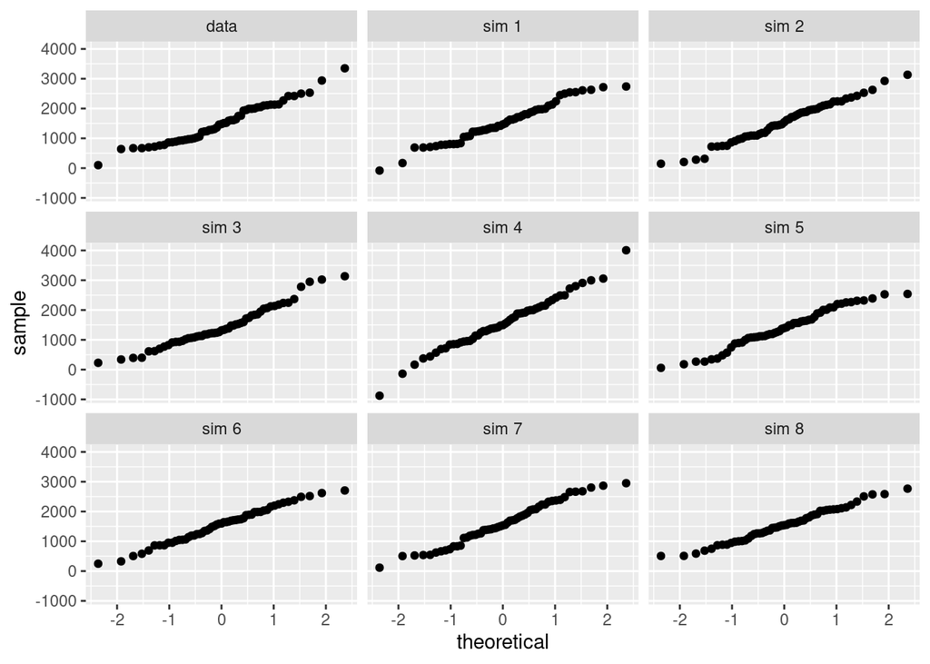

```r
qqnormsim(sample = sodium, data = arbys)
```

There appears strong evidence that sodium and cholesterol levels in the offerings at Arby’s are normally distributed.

# Exercise 7

### Now let’s consider some of the other variables in the dataset. Out of all the different restaurants, which ones’ distribution is the closest to normal for sodium?

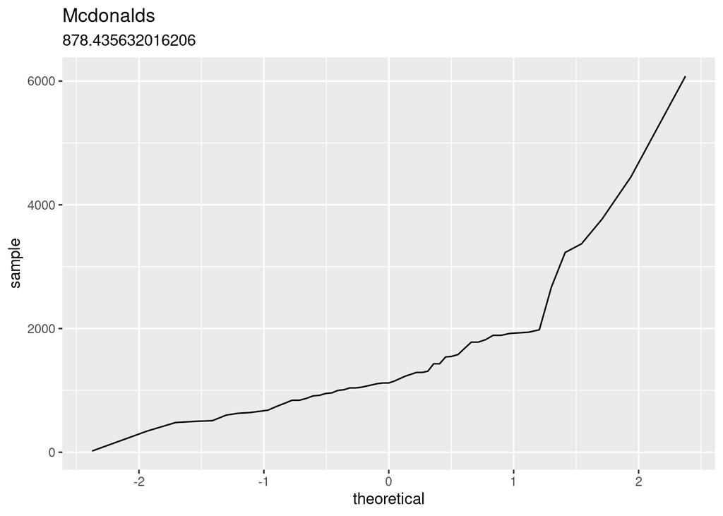

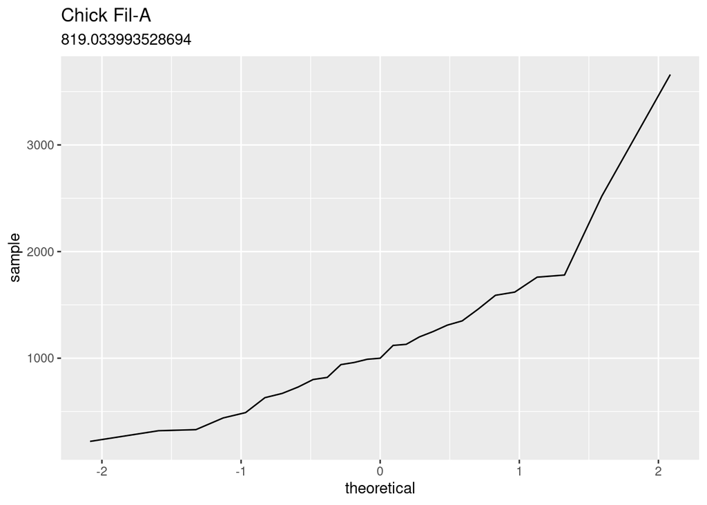

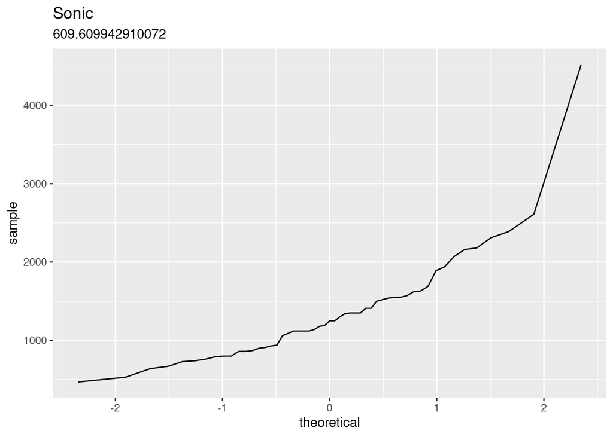

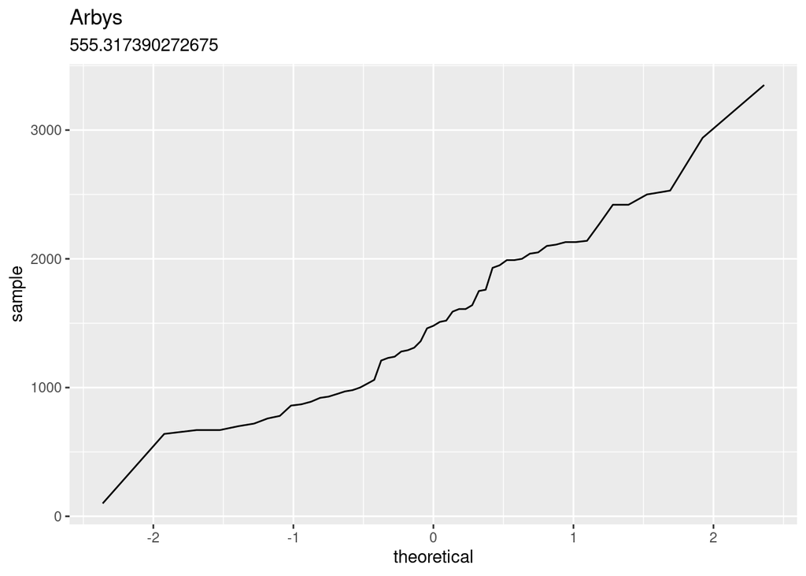

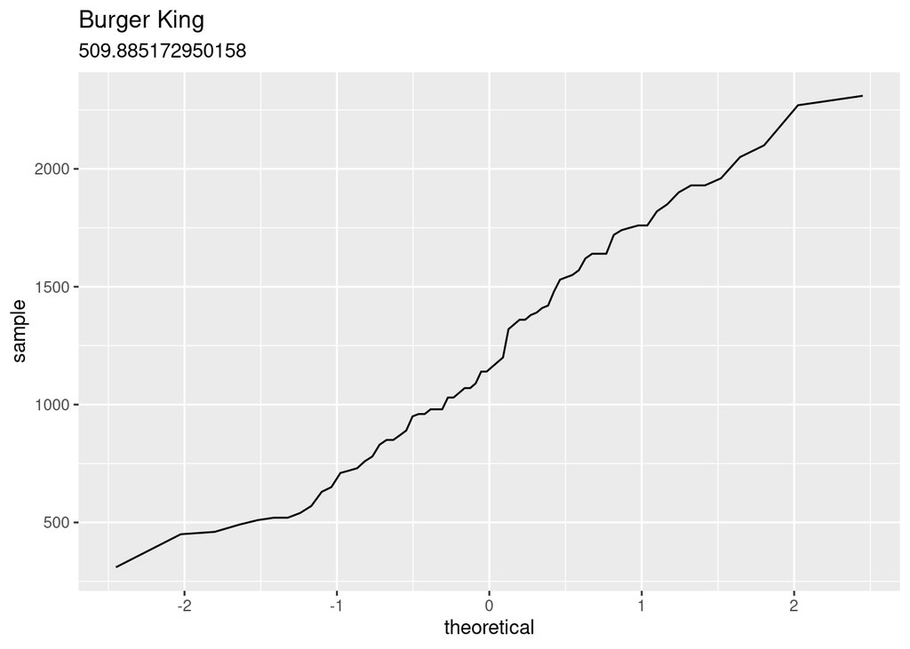

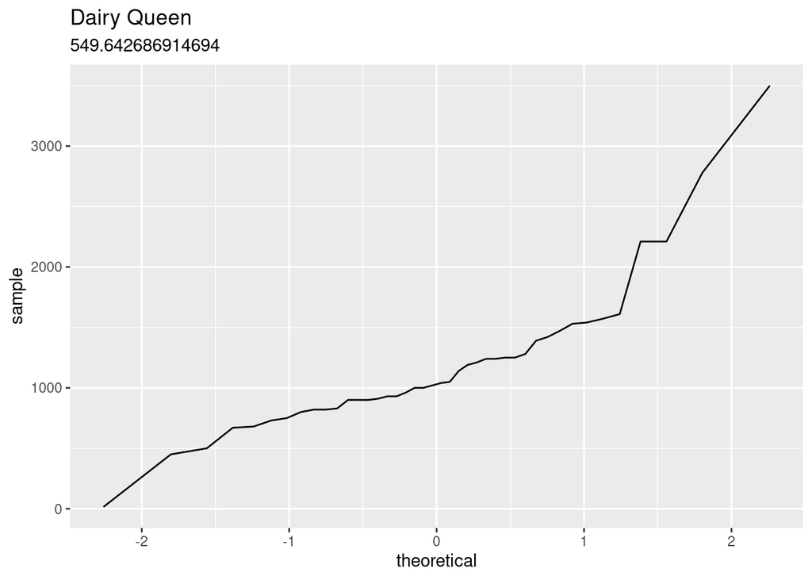

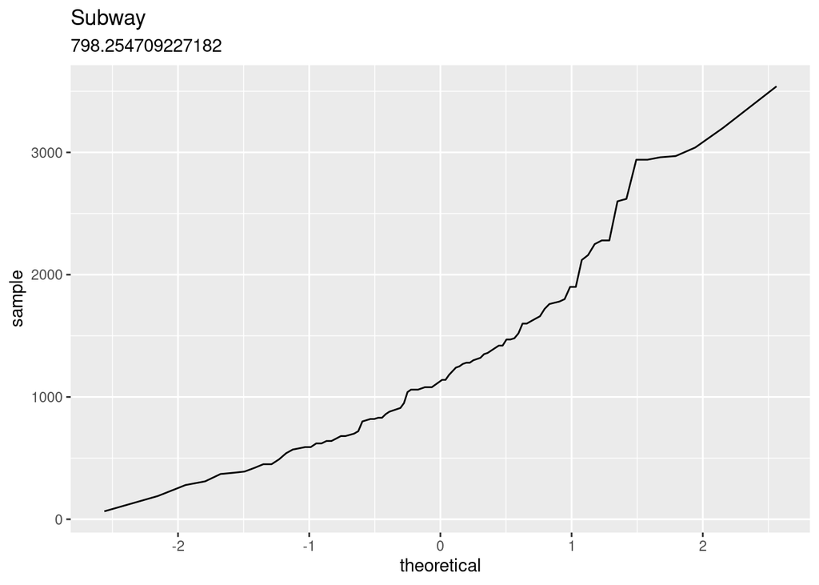

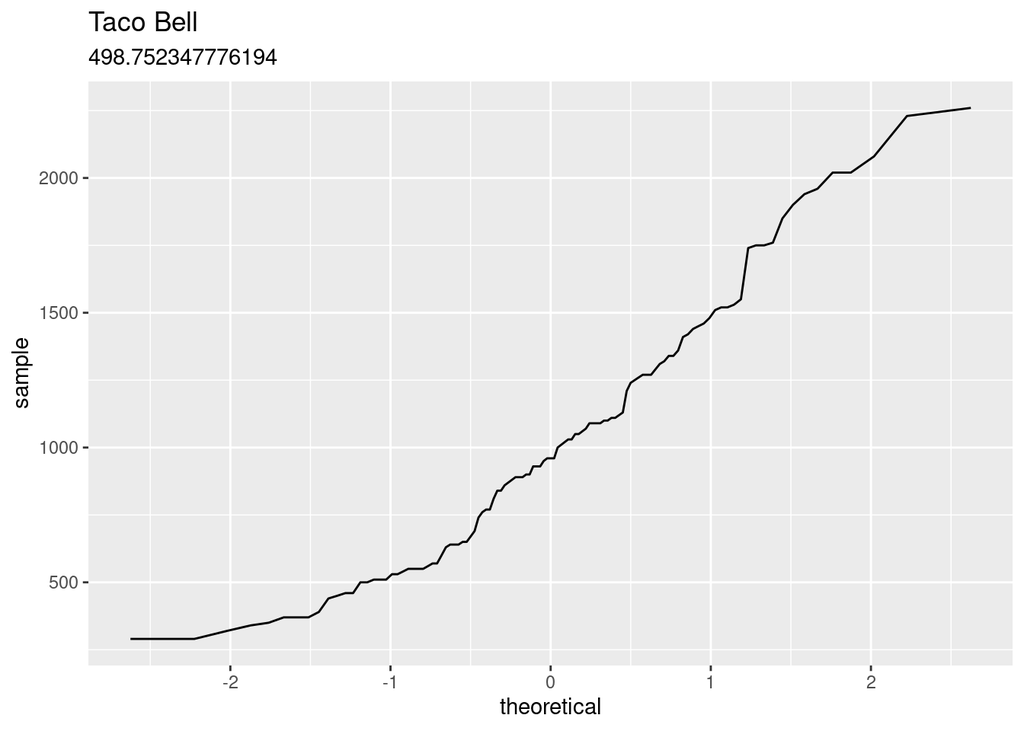

```r
sodiumNormDifference <- function(rest) {
  data <- filter(fastfood, restaurant == rest)
  sodiumNorm <- rnorm(data$sodium, mean(data$sodium), sd(data$sodium))
  return(sd(sodiumNorm - sd(data$sodium)))
}

for (rest in unique(fastfood$restaurant)) {
  print(ggplot(data = filter(fastfood, restaurant == rest), aes(sample = sodium)) +
  geom_line(stat = "qq") +
    labs(title = rest,
         subtitle = sodiumNormDifference(rest)))
}
```

# Exercise 8

### Note that some of the normal probability plots for sodium distributions seem to have a stepwise pattern. why do you think this might be the case?

I imagine this is because there is a fixed number of ingredients that can go into an offering, and many restaurants offer groups of similar food items.

# Exercise 9

### As you can see, normal probability plots can be used both to assess normality and visualize skewness. Make a normal probability plot for the total carbohydrates from a restaurant of your choice. Based on this normal probability plot, is this variable left skewed, symmetric, or right skewed? Use a histogram to confirm your findings.

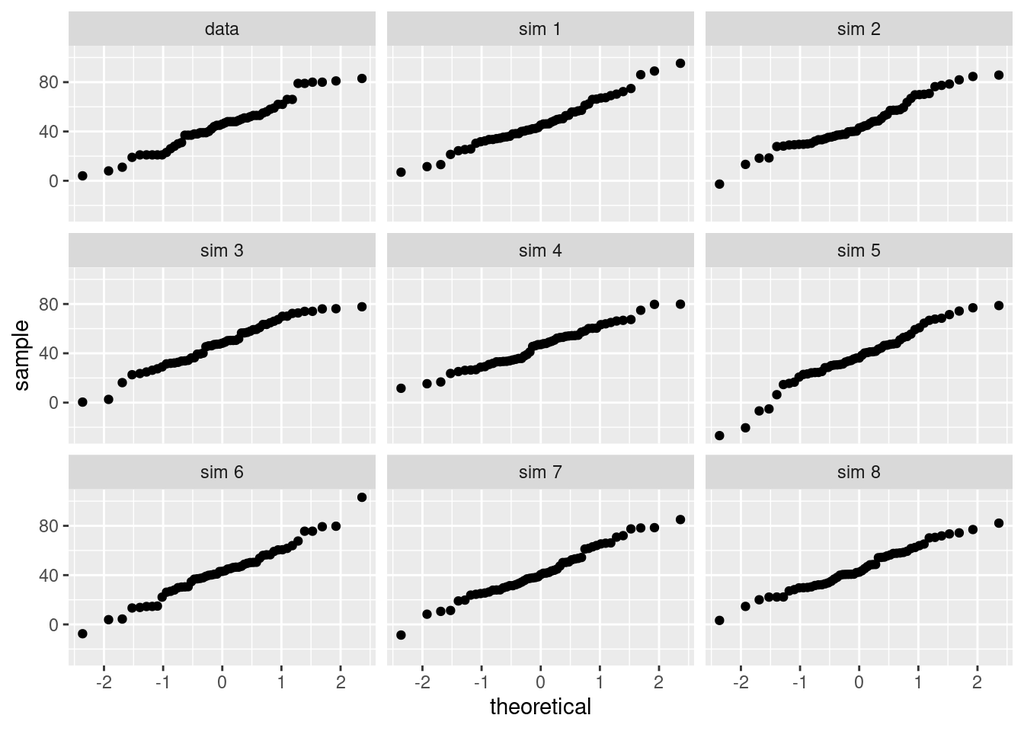

```r
qqnormsim(sample = total_carb, data = arbys)
```

The total carbs at Arby’s appear nearly normally distributed and symmetric… but not quite.

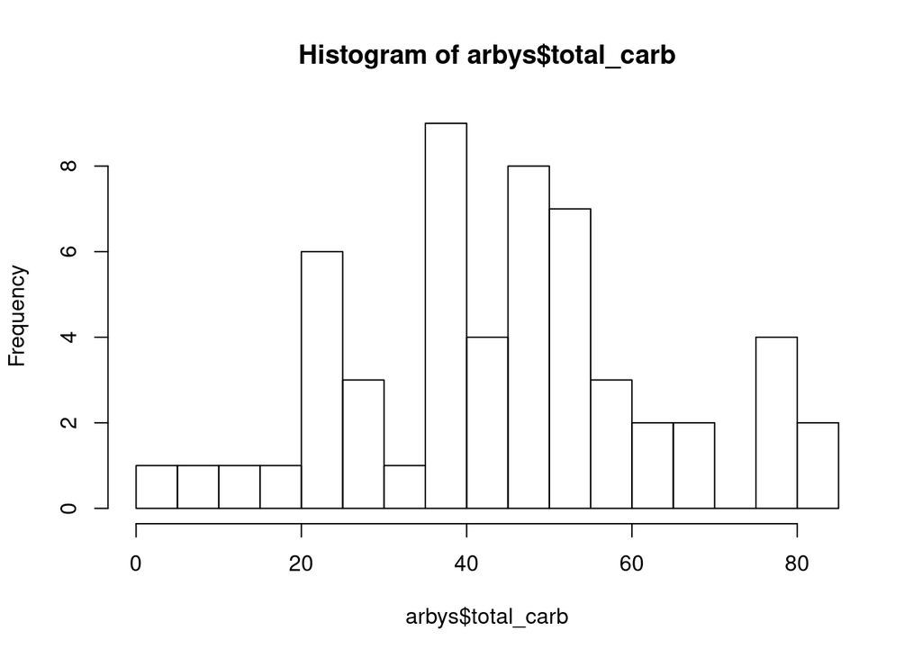

```r
hist(arbys$total_carb, breaks = 15)
```

After looking at the histogram, the data seem skewed left and polymodal.